# Lab_14T

36-600

Fall 2022

This week’s lab is very much do-it-yourself. On `Canvas`, under `Files > DATA`, there is a file called `creditDefault.csv`. Your boss wants to know if any of the variables included in this file, apart from `Default` itself, are important for predicting whether a person will default rather than paying back their credit-card balance.

From the information above, you should construct an appropriate answer. Note that regardless of whether you think a non-ML model is sufficient, you should always check to see if an ML model gives much better predictive results. Also note that your boss is not necessarily looking for plots here…but you’d always want to do *some* EDA, if for no other reason than to ensure you don’t have missing data or outliers!

```r
library(tidyverse)
library(bestglm)

df <- read.csv("Data/creditDefault.csv", header = TRUE, stringsAsFactors=TRUE)
```

```r
summary(df)
```

```
##  Student      Balance         Income      Default
##  No :921   Min.   :   0   Min.   : 4985   No :1000
##  Yes:412   1st Qu.: 630   1st Qu.:20781   Yes: 333
##            Median :1035   Median :33778
##            Mean   :1067   Mean   :33254
##            3rd Qu.:1497   3rd Qu.:43883
##            Max.   :2654   Max.   :70701
```

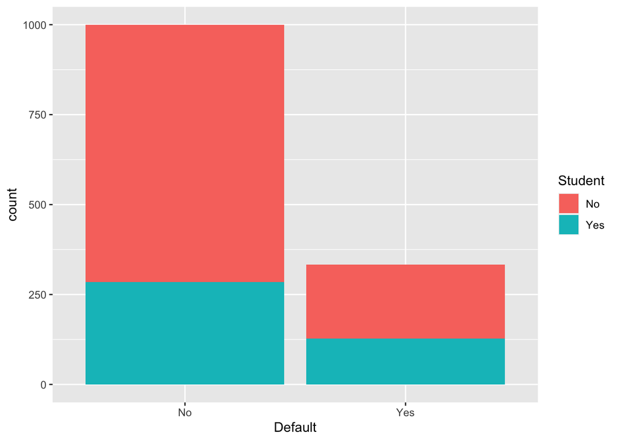

```r
ggplot(data = df, aes(x=Default, fill=Student)) +
  geom_bar()
```

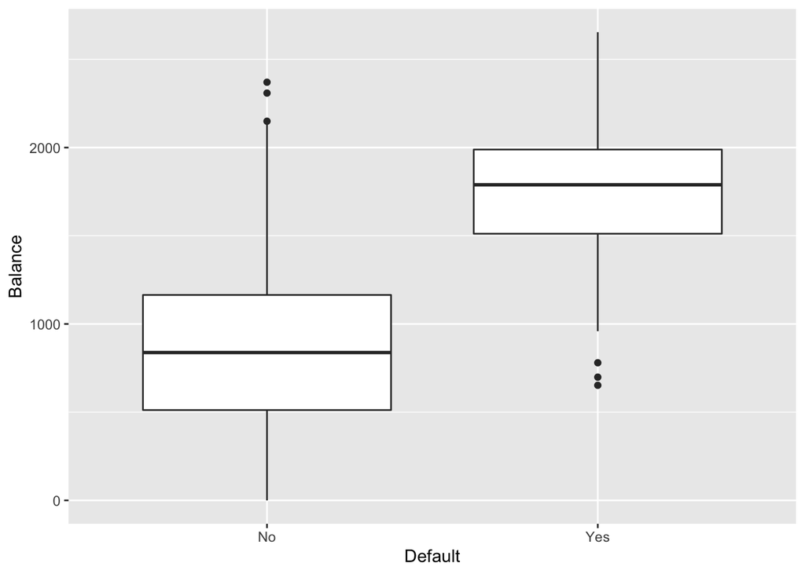

```r
ggplot(data = df, aes(x=Default, y=Balance)) +
  geom_boxplot()
```

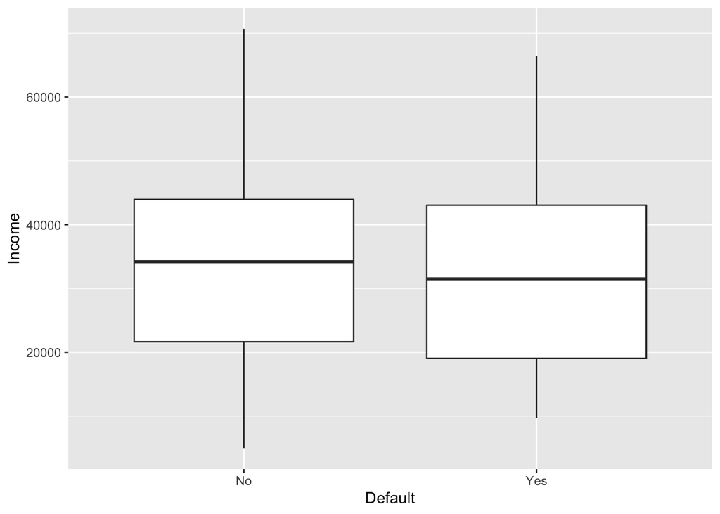

```r
ggplot(data = df, aes(x=Default, y=Income)) +
  geom_boxplot()
```

By showing the bar and box plots between predictor and response variables, we can clearly see that there might be some important relationships. For example, non-students tend to have no `Default`, and people who have lower Balance also tend to have no `Default`.

```r
set.seed(1)
s <- sample(nrow(df), round(0.7*nrow(df)))
df.train <- df[s,]
df.test <- df[-s,]

y <- df.train$Default
df.train <- df.train[,-4]
df.train <- data.frame(df.train,"y"=y)

y <- df.test$Default
df.test <- df.test[,-4]
df.test <- data.frame(df.test,"y"=y)
```

```r
bg.out <- bestglm(df.train, family = binomial, IC = "AIC")
bg.out$BestModel
```

```
##
## Call:  glm(formula = y ~ ., family = family, data = Xi, weights = weights)
##
## Coefficients:
## (Intercept)   StudentYes      Balance
##   -8.642497    -0.843969     0.005871
##
## Degrees of Freedom: 932 Total (i.e. Null);  930 Residual
## Null Deviance:       1055
## Residual Deviance: 459.2     AIC: 465.2
```

Use the bestglm to perform best subset selection on the training data. There are 2 predictor variables retained in the best models. They are `Student` and `Balance`, which conforms to our conjecture in the EDA.

```r
summary(bg.out$BestModel)
```

```
##
## Call:
## glm(formula = y ~ ., family = family, data = Xi, weights = weights)
##
## Deviance Residuals:
##      Min        1Q    Median        3Q       Max
## -2.52004  -0.33079  -0.11543   0.08913   3.01719
##
## Coefficients:
##               Estimate Std. Error z value Pr(>|z|)
## (Intercept) -8.6424971  0.5911325 -14.620  < 2e-16 ***
## StudentYes  -0.8439692  0.2618430  -3.223  0.00127 **
## Balance      0.0058712  0.0004111  14.283  < 2e-16 ***
## ---
## Signif. codes:  0 '***' 0.001 '**' 0.01 '*' 0.05 '.' 0.1 ' ' 1
##
## (Dispersion parameter for binomial family taken to be 1)
##
##     Null deviance: 1055.32  on 932  degrees of freedom
## Residual deviance:  459.16  on 930  degrees of freedom
## AIC: 465.16
##
## Number of Fisher Scoring iterations: 7
```